# Stat 218 - SVM Congress

## Variable Importance Democratic Minority Bills

```r
#dataset of democratic minority bills
demminor <- data |>
  filter(Date.of.Introduction >= as.Date("2017-01-20") & Date.of.Introduction <= as.Date("2019-01-03") &
           Party.of.Sponsor == "Democratic") |>
  select(Status, Number.of.Related.Bills, Number.of.Cosponsors, Legislation.Type, starts_with("Topic_")) |>
  mutate(Status = ifelse(Status %in% c("became_law", "passed_both"), 1, 0))

#topic analysis
topics_analysis1 <- demminor |>
  filter(Status == 1) |>
  summarise(across(starts_with("Topic_"), sum, na.rm = TRUE)) |>
  pivot_longer(
    cols = starts_with("Topic_"),
    names_to = "Topic",
    values_to = "Passed_Bills") |>
  mutate(Topic = gsub("Topic_", "", Topic)) |>
  arrange(desc(Passed_Bills))
```

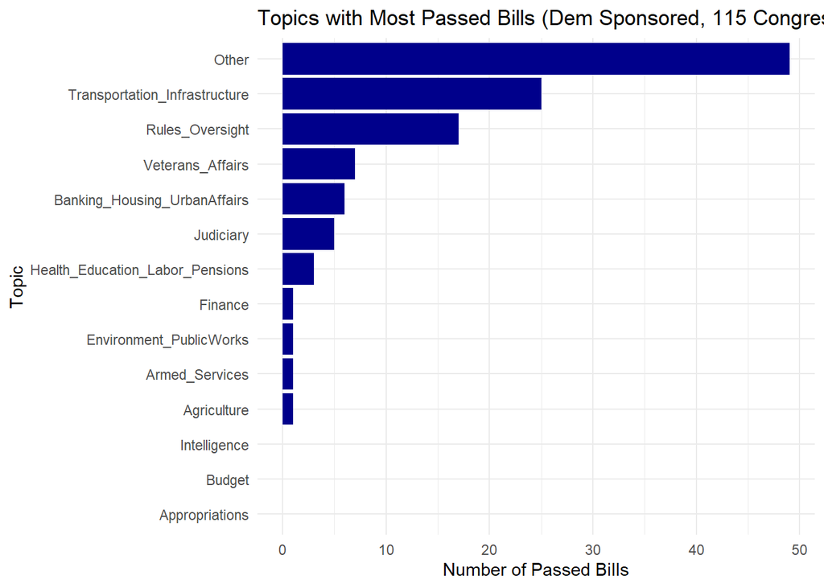

```r
#ggplot graphs of topics with most bills passed
ggplot(topics_analysis1, aes(x = reorder(Topic, Passed_Bills), y = Passed_Bills)) +
  geom_bar(stat = "identity", fill = "darkblue") +
  coord_flip() +
  labs(title = "Topics with Most Passed Bills (Dem Sponsored, 115 Congress)",
       x = "Topic", y = "Number of Passed Bills") +
  theme_minimal()
```

```r
#create training and test sets (0.7 to 0.3)
set.seed(1)
train_index_d <- createDataPartition(demminor$Status, p = 0.7, list = FALSE)
train_data_d <- demminor[train_index_d, ]
test_data_d <- demminor[-train_index_d, ]

train_data_d$Status <- as.factor(train_data_d$Status)
test_data_d$Status <- as.factor(test_data_d$Status)

topic_columns_d <- colnames(demminor)[grepl("^Topic_", colnames(demminor))]


#train the Random Forest model including topic dummies (-taxes, house admin, homeland sec, foreign affairs, small business, Indian affairs, energy commerce)
rf_model_d <- randomForest(Status ~ Number.of.Cosponsors + Number.of.Related.Bills + Legislation.Type + Topic_Health_Education_Labor_Pensions + Topic_Transportation_Infrastructure + Topic_Judiciary + Topic_Rules_Oversight + Topic_Veterans_Affairs + Topic_Finance + Topic_Armed_Services + Topic_Agriculture + Topic_Budget + Topic_Intelligence + Topic_Banking_Housing_UrbanAffairs + Topic_Appropriations  + Topic_Environment_PublicWorks,
  data = train_data_d[, c("Status", "Number.of.Cosponsors", "Number.of.Related.Bills", "Legislation.Type", topic_columns_d)],
  importance = TRUE,
  ntree = 1000)

#test predictions
test_predictions_d <- predict(rf_model_d, newdata = test_data_d)

#accuracy
accuracy_d <- mean(test_predictions_d == test_data_d$Status)

print(paste("Accuracy:", round(accuracy_d * 100, 2), "%"))
```

```
## [1] "Accuracy: 66.14 %"
```

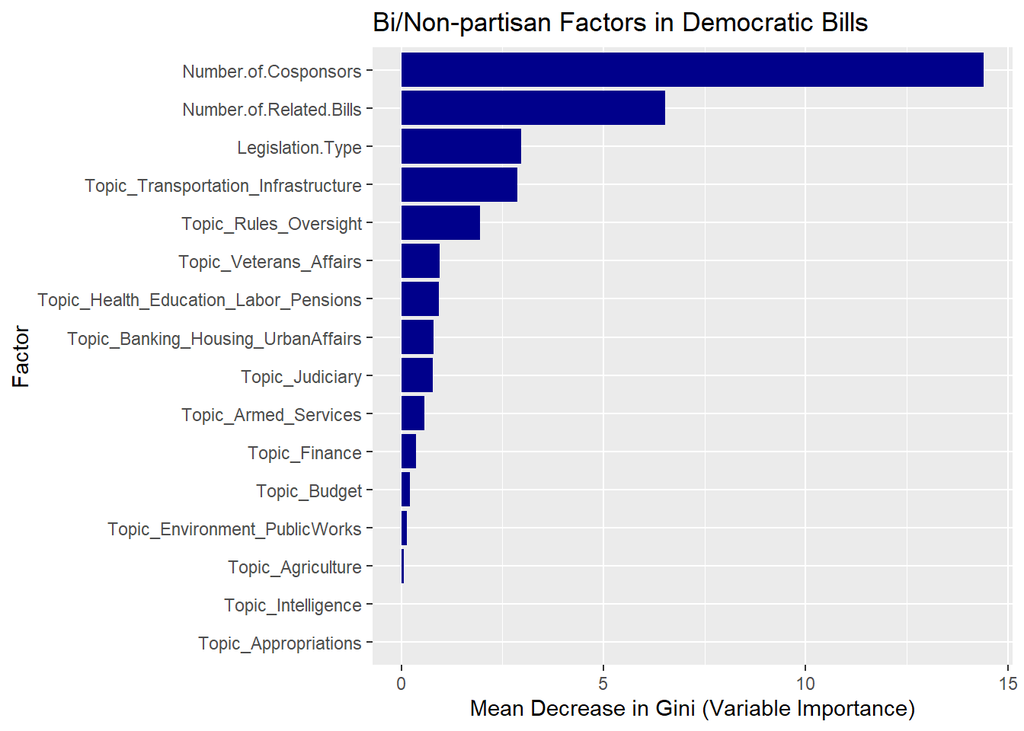

```r
#plot importance factors
importance_d <- as.data.frame(rf_model_d$importance) |>
  rownames_to_column(var = "Variable") |>
  arrange(desc(MeanDecreaseGini))

importance_d |>
  ggplot(aes(x = reorder(Variable, MeanDecreaseGini), y = MeanDecreaseGini)) +
  geom_bar(stat = "identity", fill = "darkblue") +
  coord_flip() +
  labs(title = "Bi/Non-partisan Factors in Democratic Bills", x = "Factor", y = "Mean Decrease in Gini (Variable Importance)")
```

### 1st graph, Topics for Most Passed Bills:

The data shows that Democratic-sponsored bills in the 115th Congress most frequently succeeded in broad, less partisan topics like Transportation Infrastructure and Rules Oversight, while more controversial or specialized areas saw little to no success. The dominance of the “Other” category suggests a significant share of passed bills addressed procedural or niche issues that did not fall into standard committee topics, likely making them less contentious.

### 2nd graph, Variable Importance:

The Random Forest model achieved an accuracy of 66.14%, highlighting its moderate ability to predict which Democratic-sponsored bills are likely to pass. The top predictors of success include the Number of Cosponsors and the Number of Related Bills, emphasizing the importance of building legislative coalitions and interconnected bill support. Additionally, topics like Transportation Infrastructure, Rules Oversight, and Veterans Affairs emerged as key bipartisan areas.

## Republican Variable Importance

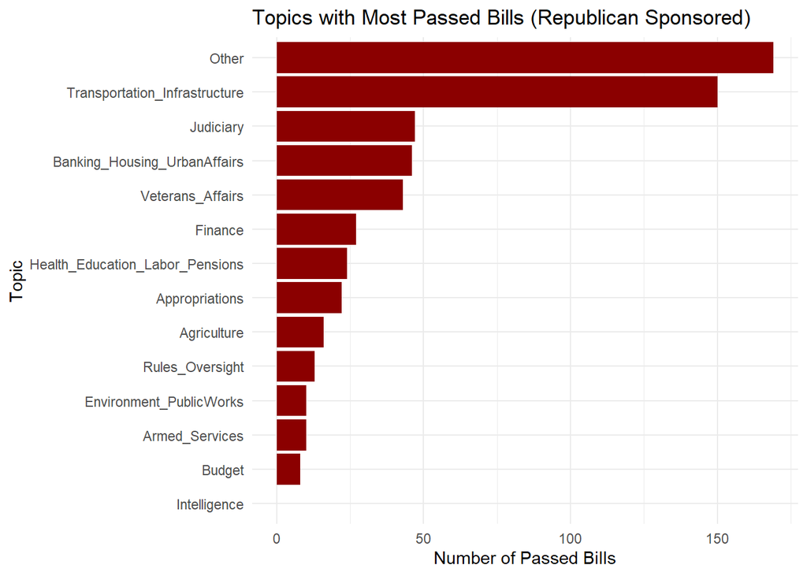

```r
#create republican set
date_range1_start <- as.Date("2021-01-20")
date_range1_end <- as.Date("2022-01-20")
date_range2_start <- as.Date("2023-01-03")
date_range2_end <- as.Date("2024-12-31")

#create republican minority set
repminor <- data |>
  filter((Date.of.Introduction >= date_range1_start & Date.of.Introduction <= date_range1_end) |
    (Date.of.Introduction >= date_range2_start & Date.of.Introduction <= date_range2_end),
    Party.of.Sponsor == "Republican") |>
  select(Date.of.Introduction, Status, Number.of.Cosponsors, Number.of.Related.Bills, Legislation.Type, starts_with("Topic_")) |>
  mutate(Status = ifelse(Status %in% c("became_law", "passed_both"), 1,
                         ifelse(Date.of.Introduction >= date_range2_start & Date.of.Introduction <= date_range2_end & Status == "passed_house", 1, 0))) |>
  mutate(across(c(Legislation.Type), as.factor))

#topic analysis
topics_analysis2 <- repminor |>
  filter(Status == 1) |>
  summarise(across(starts_with("Topic_"), sum, na.rm = TRUE)) |>
  pivot_longer(
    cols = starts_with("Topic_"), names_to = "Topic", values_to = "Passed_Bills") |>
  mutate(Topic = gsub("Topic_", "", Topic)) |>
  arrange(desc(Passed_Bills))

#plot topic analysis
ggplot(topics_analysis2, aes(x = reorder(Topic, Passed_Bills), y = Passed_Bills)) +
  geom_bar(stat = "identity", fill = "darkred") +
  coord_flip() +
  labs(title = "Topics with Most Passed Bills (Republican Sponsored)",
       x = "Topic", y = "Number of Passed Bills") +
  theme_minimal()
```

```r
#Create training and testing sets
set.seed(2)
train_index_r <- createDataPartition(repminor$Status, p = 0.7, list = FALSE)
train_data_r <- repminor[train_index_r, ]
test_data_r <- repminor[-train_index_r, ]

train_data_r$Status <- as.factor(train_data_r$Status)
test_data_r$Status <- as.factor(test_data_r$Status)

#identify topic columns
topic_columns_r <- colnames(repminor)[grepl("^Topic_", colnames(repminor))]

#train the Random Forest model including topic dummies
rf_model_r <- randomForest(Status ~ Number.of.Cosponsors + Number.of.Related.Bills + Legislation.Type + Topic_Health_Education_Labor_Pensions + Topic_Transportation_Infrastructure + Topic_Judiciary + Topic_Rules_Oversight + Topic_Veterans_Affairs + Topic_Finance + Topic_Armed_Services + Topic_Agriculture + Topic_Budget + Topic_Banking_Housing_UrbanAffairs + Topic_Appropriations  + Topic_Environment_PublicWorks,
  data = train_data_r[, c("Status", "Number.of.Cosponsors", "Number.of.Related.Bills", "Legislation.Type", topic_columns_r)],
  importance = TRUE,
  ntree = 1000)

#test for accuracy
test_predictions_r <- predict(rf_model_r, newdata = test_data_r)

accuracy_r <- mean(test_predictions_r == test_data_r$Status)
print(paste("Accuracy:", round(accuracy_r * 100, 2), "%"))
```

```
## [1] "Accuracy: 79.08 %"
```

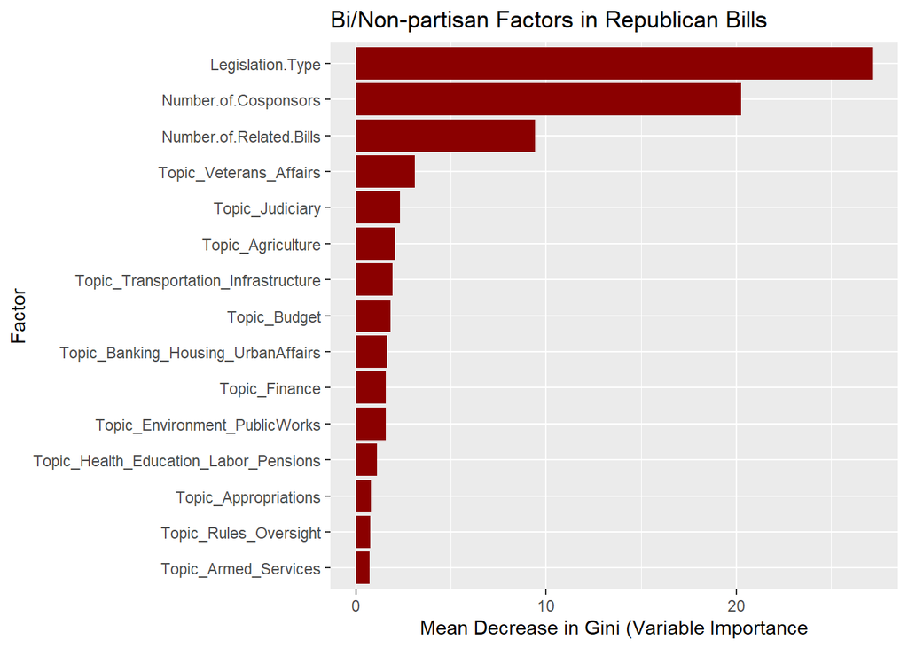

```r
#plot importance
importance_df_r <- as.data.frame(rf_model_r$importance) |>
  rownames_to_column(var = "Variable") |>
  arrange(desc(MeanDecreaseGini)) # Use the correct column name

importance_df_r |>
  ggplot(aes(x = reorder(Variable, MeanDecreaseGini), y = MeanDecreaseGini)) +
  geom_bar(stat = "identity", fill = "darkred") +
  coord_flip() +
  labs(title = "Bi/Non-partisan Factors in Republican Bills", x = "Factor", y = "Mean Decrease in Gini (Variable Importance")
```

#### 1st graph, Topics for most passed bills:

Republican-sponsored bills show significant success in Transportation Infrastructure and Judiciary, reflecting a focus on topics with broad appeal and clear governance priorities. The high number of passed bills in Banking, Housing, and Urban Affairs and Veterans Affairs highlights their emphasis on economic policy and support for military communities. While Democrats also succeeded in Transportation Infrastructure, Republicans had a broader spread of passed bills across Finance and Health Education Labor Pensions, suggesting a focus on practical, bipartisan issues.

#### 2nd graph, variable importance:

The Random Forest model for Republican-sponsored bills achieved a high accuracy of 79.08%, likely due to the larger sample size in the repminor dataset. Just like with Democratic bills, key predictors of success include Legislation Type, Number of Cosponsors, and Number of Related Bills, emphasizing the importance of coalition-building and interconnected legislative efforts. Additionally, topics like Veterans Affairs and Judiciary emerged as significant factors.